# Assignment_2

Cole Yagersz

```r
#Load the libraries being used
library("caret")
library("dplyr")
#Read in csv file to data frame
retail <- read.csv("Online_Retail.csv")

#Preview data
head(retail)
```

```
##   InvoiceNo StockCode                         Description Quantity
## 1    536365    85123A  WHITE HANGING HEART T-LIGHT HOLDER        6
## 2    536365     71053                 WHITE METAL LANTERN        6
## 3    536365    84406B      CREAM CUPID HEARTS COAT HANGER        8
## 4    536365    84029G KNITTED UNION FLAG HOT WATER BOTTLE        6
## 5    536365    84029E      RED WOOLLY HOTTIE WHITE HEART.        6
## 6    536365     22752        SET 7 BABUSHKA NESTING BOXES        2
##      InvoiceDate UnitPrice CustomerID        Country
## 1 12/1/2010 8:26      2.55      17850 United Kingdom
## 2 12/1/2010 8:26      3.39      17850 United Kingdom
## 3 12/1/2010 8:26      2.75      17850 United Kingdom
## 4 12/1/2010 8:26      3.39      17850 United Kingdom
## 5 12/1/2010 8:26      3.39      17850 United Kingdom
## 6 12/1/2010 8:26      7.65      17850 United Kingdom
```

Question 1:Show the breakdown of the number of transactions by countries i.e., how many transactions are in the dataset for each country (consider all records including cancelled transactions). Show this in total number and also in percentage. Show only countries accounting for more than 1% of the total transactions.

```r
# Count transactions per country
country_count <- retail %>%
group_by(Country) %>%
summarise(TransactionCount = n()) %>%
mutate(Percentage = 100 * TransactionCount/ sum(TransactionCount)) %>%
filter(Percentage >1)

#View the results
print(country_count)
```

```
## # A tibble: 4 × 3
##   Country        TransactionCount Percentage
##   <chr>                     <int>      <dbl>
## 1 EIRE                       8196       1.51
## 2 France                     8557       1.58
## 3 Germany                    9495       1.75
## 4 United Kingdom           495478      91.4
```

Question 2: Create a new variable ‘TransactionValue’ that is the product of the existing ‘Quantity’ and ‘UnitPrice’ variables. Add this variable to the dataframe.

```r
retail <- retail %>%
mutate(TransactionValue = Quantity * UnitPrice)

summary(retail)
```

```
##   InvoiceNo          StockCode         Description           Quantity
##  Length:541909      Length:541909      Length:541909      Min.   :-80995.000
##  Class :character   Class :character   Class :character   1st Qu.:     1.000
##  Mode  :character   Mode  :character   Mode  :character   Median :     3.000
##                                                           Mean   :     9.552
##                                                           3rd Qu.:    10.000
##                                                           Max.   : 80995.000
##
##  InvoiceDate          UnitPrice            CustomerID       Country
##  Length:541909      Min.   :-11062.060   Min.   :12346    Length:541909
##  Class :character   1st Qu.:     1.250   1st Qu.:13953    Class :character
##  Mode  :character   Median :     2.080   Median :15152    Mode  :character
##                     Mean   :     4.611   Mean   :15288
##                     3rd Qu.:     4.130   3rd Qu.:16791
##                     Max.   : 38970.000   Max.   :18287
##                                          NA's   :135080
##  TransactionValue
##  Min.   :-168469.60
##  1st Qu.:      3.40
##  Median :      9.75
##  Mean   :     17.99
##  3rd Qu.:     17.40
##  Max.   : 168469.60
##
```

Question 3: Using the newly created variable, TransactionValue, show the breakdown of transaction values by countries i.e. how much money in total has been spent each country. Show this in total sum of transaction values. Show only countries with total transaction exceeding 130,000 British Pound.

```r
# Group by country and sum TransactionValue
country_transaction <- retail %>%
group_by(Country) %>%
summarise(TotalValue = sum(TransactionValue, na.rm = TRUE)) %>%
filter(TotalValue > 130000) %>%
arrange(desc(TotalValue))

# Show countries transactions greater than $130000
print(country_transaction)
```

```
## # A tibble: 6 × 2
##   Country        TotalValue
##   <chr>               <dbl>
## 1 United Kingdom   8187806.
## 2 Netherlands       284662.
## 3 EIRE              263277.
## 4 Germany           221698.
## 5 France            197404.
## 6 Australia         137077.
```

Question 4

```r
# Change into POSIXIt
Temp=strptime(retail$InvoiceDate,format='%m/%d/%Y %H:%M',tz='GMT')

head(Temp)
```

```
## [1] "2010-12-01 08:26:00 GMT" "2010-12-01 08:26:00 GMT"
## [3] "2010-12-01 08:26:00 GMT" "2010-12-01 08:26:00 GMT"
## [5] "2010-12-01 08:26:00 GMT" "2010-12-01 08:26:00 GMT"
```

```r
# separate date, day of the week and hour components
retail$New_Invoice_Date <- as.Date(Temp)

retail$New_Invoice_Date[20000]- retail$New_Invoice_Date[10]
```

```
## Time difference of 8 days
```

```r
retail$Invoice_Day_Week= weekdays(retail$New_Invoice_Date)

retail$New_Invoice_Hour = as.numeric(format(Temp, "%H"))

retail$New_Invoice_Month = as.numeric(format(Temp, "%m"))

# Show the percentage of transactions (by numbers) by days of the week
retail %>%
group_by(Invoice_Day_Week) %>%
summarise(TransactionCount = n()) %>%
mutate(Percentage = 100 * TransactionCount / sum(TransactionCount)) %>%
arrange(desc(Percentage))
```

```
## # A tibble: 6 × 3
##   Invoice_Day_Week TransactionCount Percentage
##   <chr>                       <int>      <dbl>
## 1 Thursday                   103857       19.2
## 2 Tuesday                    101808       18.8
## 3 Monday                      95111       17.6
## 4 Wednesday                   94565       17.5
## 5 Friday                      82193       15.2
## 6 Sunday                      64375       11.9
```

```r
# Show the percentage of transactions (by transaction volume) by days of the week
retail %>%
group_by(Invoice_Day_Week) %>%
summarise(TotalValue = sum(TransactionValue, na.rm = TRUE)) %>%
mutate(Percentage = 100 * TotalValue / sum(TotalValue)) %>%
arrange(desc(Percentage))
```

```
## # A tibble: 6 × 3
##   Invoice_Day_Week TotalValue Percentage
##   <chr>                 <dbl>      <dbl>
## 1 Thursday           2112519       21.7
## 2 Tuesday            1966183.      20.2
## 3 Wednesday          1734147.      17.8
## 4 Monday             1588609.      16.3
## 5 Friday             1540611.      15.8
## 6 Sunday              805679.       8.27
```

```r
# Show the percentage of transactions (by transaction volume) by month of the year
retail %>%
group_by(New_Invoice_Month) %>%
summarise(TotalValue = sum(TransactionValue, na.rm = TRUE)) %>%
mutate(Percentage = 100 * TotalValue / sum(TotalValue)) %>%
arrange(New_Invoice_Month)
```

```
## # A tibble: 12 × 3
##    New_Invoice_Month TotalValue Percentage
##                <dbl>      <dbl>      <dbl>
##  1                 1    560000.       5.74
##  2                 2    498063.       5.11
##  3                 3    683267.       7.01
##  4                 4    493207.       5.06
##  5                 5    723334.       7.42
##  6                 6    691123.       7.09
##  7                 7    681300.       6.99
##  8                 8    682681.       7.00
##  9                 9   1019688.      10.5
## 10                10   1070705.      11.0
## 11                11   1461756.      15.0
## 12                12   1182625.      12.1
```

```r
# The date with the highest number of transactions from Australia?
retail %>%
filter(Country == "Australia") %>%
group_by(New_Invoice_Date) %>%
summarise(NumTransactions = n()) %>%
arrange(desc(NumTransactions)) %>%
slice(1)
```

```
## # A tibble: 1 × 2
##   New_Invoice_Date NumTransactions
##   <date>                     <int>
## 1 2011-06-15                   139
```

```r
#  Minimum for the customers? The responsible IT team is available from 7:00 to 20:00 every day.
hourly_counts <- retail %>%
filter(New_Invoice_Hour >= 7 & New_Invoice_Hour <= 20) %>%
group_by(New_Invoice_Hour) %>%
summarise(TransactionCount = n()) %>%
arrange(New_Invoice_Hour)


# Extract vectors from hourly_counts
hours <- hourly_counts$New_Invoice_Hour
counts <- hourly_counts$TransactionCount

# Create a vector of rolling 2-hour sums
rolling_2hr <- counts[1:(length(counts)-1)] + counts[2:length(counts)]

# Create a data frame to see the 2-hour windows and their total transactions
two_hour_windows <- data.frame(
Start_Hour = hours[1:(length(hours)-1)],
End_Hour = hours[2:length(hours)],
Total_Transactions = rolling_2hr)

# View the lowest traffic window
two_hour_windows %>%
arrange(Total_Transactions) %>%
slice(1)
```

```
##   Start_Hour End_Hour Total_Transactions
## 1         19       20               4576
```

Question 5: Plot the histogram of transaction values from Germany. Use the hist() function to plot.

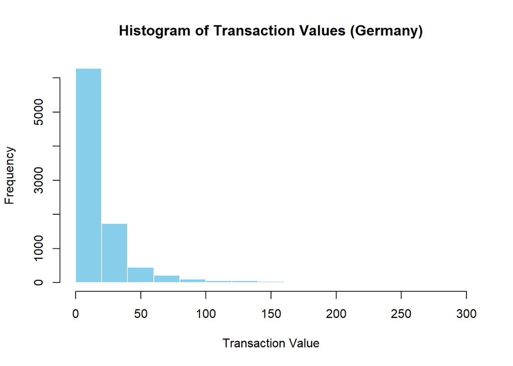

```r
# Filter data for Germany only
germany_data <- retail %>%
filter(Country == "Germany", !is.na(TransactionValue), TransactionValue > 0)

# Plot histogram of TransactionValue
hist(germany_data$TransactionValue,
     main = "Histogram of Transaction Values (Germany)",
     xlab = "Transaction Value",
     col = "skyblue",
     border = "white",
     breaks = 50,
     xlim = c(0, 300))
```

Question 6: Which customer had the highest number of transactions? Which customer is most valuable

```r
customer_data <- retail %>%
  filter(!is.na(CustomerID))

# Highest number of transactions
most_transactions <- customer_data %>%
group_by(CustomerID) %>%
summarise(NumTransactions = n_distinct(InvoiceNo)) %>%
arrange(desc(NumTransactions)) %>%
slice(1)

print(most_transactions)
```

```
## # A tibble: 1 × 2
##   CustomerID NumTransactions
##        <int>           <int>
## 1      14911             248
```

```r
# Most valuable customer
most_valuable <- customer_data %>%
group_by(CustomerID) %>%
summarise(TotalSpent = sum(TransactionValue, na.rm = TRUE)) %>%
arrange(desc(TotalSpent)) %>%
slice(1)

print(most_valuable)
```

```
## # A tibble: 1 × 2
##   CustomerID TotalSpent
##        <int>      <dbl>
## 1      14646    279489.
```

Question 7: Calculate the percentage of missing values for each variable in the dataset

```r
missing_percentages <- colMeans(is.na(retail)) * 100
print(missing_percentages)
```

```
##         InvoiceNo         StockCode       Description          Quantity
##           0.00000           0.00000           0.00000           0.00000
##       InvoiceDate         UnitPrice        CustomerID           Country
##           0.00000           0.00000          24.92669           0.00000
##  TransactionValue  New_Invoice_Date  Invoice_Day_Week  New_Invoice_Hour
##           0.00000           0.00000           0.00000           0.00000
## New_Invoice_Month
##           0.00000
```

Question 8: What are the number of transactions with missing CustomerID records by countries?

```r
retail %>%
filter(is.na(CustomerID)) %>%
group_by(Country) %>%
summarise(MissingTransactions = n()) %>%
arrange(desc(MissingTransactions))
```

```
## # A tibble: 9 × 2
##   Country        MissingTransactions
##   <chr>                        <int>
## 1 United Kingdom              133600
## 2 EIRE                           711
## 3 Hong Kong                      288
## 4 Unspecified                    202
## 5 Switzerland                    125
## 6 France                          66
## 7 Israel                          47
## 8 Portugal                        39
## 9 Bahrain                          2
```

Question 9: On average, how often the costumers comeback to the website for their next shopping

```r
retail$InvoiceDate <- as.POSIXct(retail$InvoiceDate, format = "%m/%d/%Y %H:%M")

# Filter out rows with missing CustomerID
return_data <- retail %>%
filter(!is.na(CustomerID)) %>%
arrange(CustomerID, InvoiceDate) %>%  # Sort by customer and date
group_by(CustomerID) %>%
mutate(DaysBetween = as.numeric(difftime(InvoiceDate, lag(InvoiceDate), units = "days")))

# Remove NA values from first purchase per customer
average_days_between <- return_data %>%
filter(!is.na(DaysBetween)) %>%
summarise(AverageDays = mean(DaysBetween))

print(average_days_between)
```

```
## # A tibble: 4,293 × 2
##    CustomerID AverageDays
##         <int>       <dbl>
##  1      12346      0.0111
##  2      12347      2.02
##  3      12348      9.42
##  4      12349      0
##  5      12350      0
##  6      12352      2.77
##  7      12353      0
##  8      12354      0
##  9      12355      0
## 10      12356      5.22
## # ℹ 4,283 more rows
```

Question 10: In the retail sector, it is very important to understand the return rate of the goods purchased by customers. In this example, we can define this quantity, simply, as the ratio of the number of transactions cancelled (regardless of the transaction value) over the total number of transactions.Page 4 With this definition, what is the return rate for the French customers?

```r
return_rate_france <- retail %>%
filter(Country == "France") %>%
summarise(Total = n(),
Cancelled = sum(Quantity < 0),
ReturnRate = Cancelled / Total * 100)

print(return_rate_france)
```

```
##   Total Cancelled ReturnRate
## 1  8557       149   1.741264
```

Question 11: What is the product that has generated the highest revenue for the retailer?

```r
top_product <- retail %>%
filter(TransactionValue > 0) %>%
group_by(Description) %>%
summarise(TotalRevenue = sum(TransactionValue, na.rm = TRUE)) %>%
arrange(desc(TotalRevenue)) %>%
slice(1)

print(top_product)
```

```
## # A tibble: 1 × 2
##   Description    TotalRevenue
##   <chr>                 <dbl>
## 1 DOTCOM POSTAGE      206249.
```

Question 12: How many unique customers are represented in the dataset?

```r
# Count number of unique customers
num_unique_customers <- length(unique(retail$CustomerID[!is.na(retail$CustomerID)]))

print(num_unique_customers)
```

```
## [1] 4372
```